# Gestational Diabetes Prediction and Analysis in Pregnant Women

Ian Dsilva

2023-04-30

## Loading Libraries

```r
library(dplyr)
library(pROC)
library(tidyverse)
library(ROCR)
library(ggplot2)
library(caret)
library(Hmisc)
library(reshape2)
library(viridis)
library(glmnet)
library(pROC)
library(randomForest)
```

## Loading Dataset

```r
df_diab <- read.csv('diabetes.csv')
```

## Data Cleaning

```r
# Check for missing values
any(missing(df_diab))
```

```
## [1] FALSE
```

```r
any(is.na(df_diab))
```

```
## [1] FALSE
```

```r
sum(is.na(df_diab))
```

```
## [1] 0
```

## Exploratory Data Analysis

```r
# Describing Dataset
head(df_diab)
```

```
##   Pregnancies Glucose BloodPressure SkinThickness Insulin  BMI
## 1           6     148            72            35       0 33.6
## 2           1      85            66            29       0 26.6
## 3           8     183            64             0       0 23.3
## 4           1      89            66            23      94 28.1
## 5           0     137            40            35     168 43.1
## 6           5     116            74             0       0 25.6
##   DiabetesPedigreeFunction Age Outcome
## 1                    0.627  50       1
## 2                    0.351  31       0
## 3                    0.672  32       1
## 4                    0.167  21       0
## 5                    2.288  33       1
## 6                    0.201  30       0
```

```r
summary(df_diab)
```

```
##   Pregnancies        Glucose      BloodPressure    SkinThickness
##  Min.   : 0.000   Min.   :  0.0   Min.   :  0.00   Min.   : 0.00
##  1st Qu.: 1.000   1st Qu.: 99.0   1st Qu.: 62.00   1st Qu.: 0.00
##  Median : 3.000   Median :117.0   Median : 72.00   Median :23.00
##  Mean   : 3.845   Mean   :120.9   Mean   : 69.11   Mean   :20.54
##  3rd Qu.: 6.000   3rd Qu.:140.2   3rd Qu.: 80.00   3rd Qu.:32.00
##  Max.   :17.000   Max.   :199.0   Max.   :122.00   Max.   :99.00
##     Insulin           BMI        DiabetesPedigreeFunction      Age
##  Min.   :  0.0   Min.   : 0.00   Min.   :0.0780           Min.   :21.00
##  1st Qu.:  0.0   1st Qu.:27.30   1st Qu.:0.2437           1st Qu.:24.00
##  Median : 30.5   Median :32.00   Median :0.3725           Median :29.00
##  Mean   : 79.8   Mean   :31.99   Mean   :0.4719           Mean   :33.24
##  3rd Qu.:127.2   3rd Qu.:36.60   3rd Qu.:0.6262           3rd Qu.:41.00
##  Max.   :846.0   Max.   :67.10   Max.   :2.4200           Max.   :81.00
##     Outcome
##  Min.   :0.000
##  1st Qu.:0.000
##  Median :0.000
##  Mean   :0.349
##  3rd Qu.:1.000
##  Max.   :1.000
```

```r
describe(df_diab)
```

```
## df_diab
##
##  9  Variables      768  Observations
## --------------------------------------------------------------------------------
## Pregnancies
##        n  missing distinct     Info     Mean      Gmd      .05      .10
##      768        0       17    0.986    3.845    3.698        0        0
##      .25      .50      .75      .90      .95
##        1        3        6        9       10
##
## lowest :  0  1  2  3  4, highest: 12 13 14 15 17
##
## Value          0     1     2     3     4     5     6     7     8     9    10
## Frequency    111   135   103    75    68    57    50    45    38    28    24
## Proportion 0.145 0.176 0.134 0.098 0.089 0.074 0.065 0.059 0.049 0.036 0.031
##
## Value         11    12    13    14    15    17
## Frequency     11     9    10     2     1     1
## Proportion 0.014 0.012 0.013 0.003 0.001 0.001
## --------------------------------------------------------------------------------
## Glucose
##        n  missing distinct     Info     Mean      Gmd      .05      .10
##      768        0      136        1    120.9    35.48     79.0     85.0
##      .25      .50      .75      .90      .95
##     99.0    117.0    140.2    167.0    181.0
##
## lowest :   0  44  56  57  61, highest: 195 196 197 198 199
## --------------------------------------------------------------------------------
## BloodPressure
##        n  missing distinct     Info     Mean      Gmd      .05      .10
##      768        0       47    0.998    69.11    18.81     38.7     54.0
##      .25      .50      .75      .90      .95
##     62.0     72.0     80.0     88.0     90.0
##
## lowest :   0  24  30  38  40, highest: 106 108 110 114 122
## --------------------------------------------------------------------------------
## SkinThickness
##        n  missing distinct     Info     Mean      Gmd      .05      .10
##      768        0       51    0.974    20.54    17.93        0        0
##      .25      .50      .75      .90      .95
```

[output cut: 26 more lines]

```
## lowest : 0.078 0.084 0.085 0.088 0.089, highest: 1.893 2.137 2.288 2.329 2.420
## --------------------------------------------------------------------------------
## Age
##        n  missing distinct     Info     Mean      Gmd      .05      .10
##      768        0       52    0.998    33.24    12.62       21       22
##      .25      .50      .75      .90      .95
##       24       29       41       51       58
##
## lowest : 21 22 23 24 25, highest: 68 69 70 72 81
## --------------------------------------------------------------------------------
## Outcome
##        n  missing distinct     Info      Sum     Mean      Gmd
##      768        0        2    0.682      268    0.349    0.455
##
## --------------------------------------------------------------------------------
```

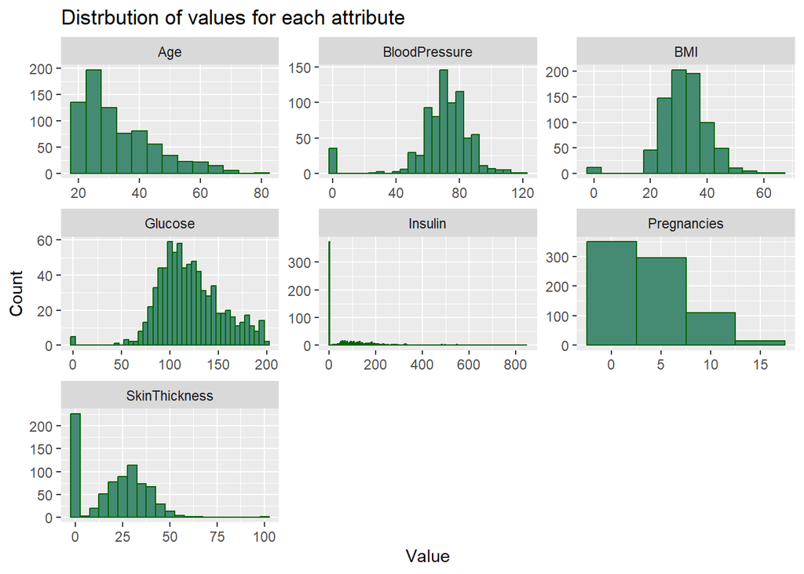

```r
# histogram for attribute
ggplot(gather(df_diab[, c(1,2,3,4,5,6,8)], variable, value), aes(x = value)) +
  geom_histogram(binwidth = 5, fill = "aquamarine4", color = "darkgreen") +
  facet_wrap(~variable, scales = "free") +
  labs(x = "Value", y = "Count", title = "Distrbution of values for each attribute")
```

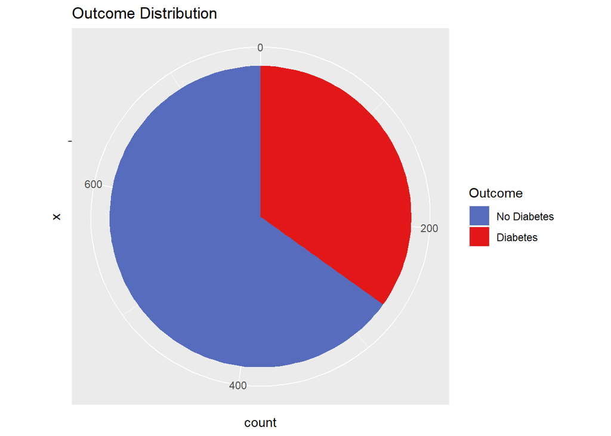

```r
# pie chart of the distribution of 0's and 1's in the Outcome variable
ggplot(df_diab, aes(x = "", fill = factor(df_diab$Outcome))) +
  geom_bar(width = 1, stat = "count") +
  scale_fill_manual(values = c("#576CBC", "#E21818"), name = "Outcome", labels = c("No Diabetes", "Diabetes")) +
  coord_polar(theta = "y") +
  labs(fill = "Outcome", title = "Outcome Distribution")
```

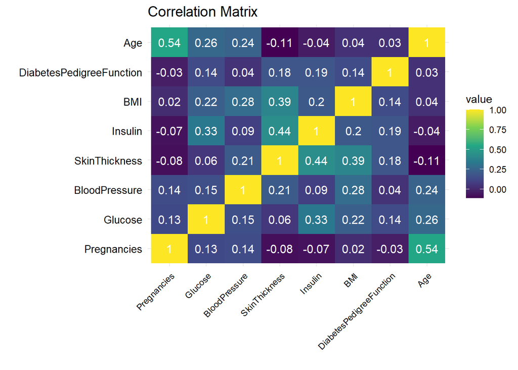

```r
df_corr <- df_diab

df_corr$Outcome <- NULL

# Computing correlation matrix
cor_matrix <- cor(df_corr)

# Converting correlation matrix to long format
cor_df <- melt(cor_matrix)

# Plotting correlation matrix
ggplot(cor_df, aes(Var1, Var2, fill = value)) +
  geom_tile() +
  geom_text(aes(label = round(value, 2)), size = 4, color = "white") +
  scale_fill_viridis_c(option = "viridis", na.value = "white") +
  labs(title = "Correlation Matrix", x = "", y = "") +
  theme_minimal() +
  theme(plot.title = element_text(size = 14),
        axis.text.x = element_text(angle = 45, hjust = 1, color = 'black'),
        axis.text.y = element_text(size = 10, color = 'black'))
```

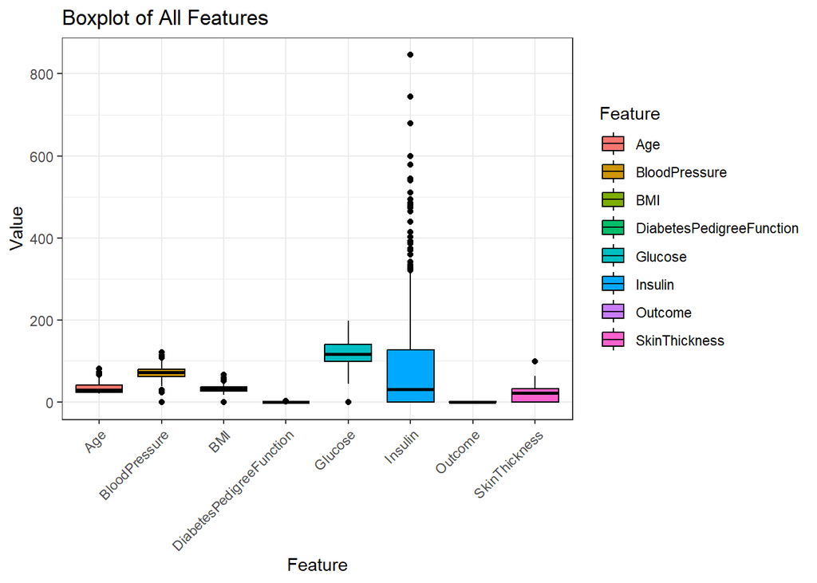

```r
## Box Plot

# Reshaping the data into long format
df_long <- tidyr::gather(df_diab, key = "Feature", value = "Value", -Pregnancies)

# Creating a boxplot of all features
ggplot(df_long, aes(x = Feature, y = Value, fill = Feature)) +
  geom_boxplot(color = "black") +
  labs(title = "Boxplot of All Features",
       x = "Feature",
       y = "Value") +
  theme_bw() +
  theme(axis.text.x = element_text(angle = 45, hjust = 1)) +
  scale_fill_discrete(name = "Feature")
```

## One Sample t-test

```r
abs(qt(p = 0.05, df = 767, lower.tail = FALSE))
```

```
## [1] 1.646843
```

```r
t.test(df_diab$BloodPressure, mu = 70, alternative = 'two.sided', conf.level = 0.90)
```

```
##
##  One Sample t-test
##
## data:  df_diab$BloodPressure
## t = -1.2808, df = 767, p-value = 0.2007
## alternative hypothesis: true mean is not equal to 70
## 90 percent confidence interval:
##  67.95524 70.25569
## sample estimates:
## mean of x
##  69.10547
```

*Results: We Fail to Reject the Null Hypothesis*

Alpha = 0.05

```r
abs(qt(p = 0.05, df = 767, lower.tail = FALSE))
```

```
## [1] 1.646843
```

```r
t.test(df_diab$Glucose, mu = 110, alternative = 'two.sided', conf.level = 0.90)
```

```
##
##  One Sample t-test
##
## data:  df_diab$Glucose
## t = 9.443, df = 767, p-value < 2.2e-16
## alternative hypothesis: true mean is not equal to 110
## 90 percent confidence interval:
##  118.9945 122.7945
## sample estimates:
## mean of x
##  120.8945
```

*Results: We Reject the Null Hypothesis*

## One Way Anova Hypothesis Testing

**Research Question: Perform a one-way ANOVA using the aov function in r to determines whether the diabetes is inherited or not?**

Null Hypothesis (H0): There is no significant difference in the mean diabetes pedigree function among different outcome.  
Alternate Hypothesis (H1): There is a significant difference in the mean diabetes pedigree function among different outcome.

```r
qf(0.95,1,766)
```

```
## [1] 3.853627
```

```r
preg_res <- aov(DiabetesPedigreeFunction ~  Outcome, data = df_diab)
preg_res
```

```
## Call:
##    aov(formula = DiabetesPedigreeFunction ~ Outcome, data = df_diab)
##
## Terms:
##                  Outcome Residuals
## Sum of Squares   2.54468  81.65554
## Deg. of Freedom        1       766
##
## Residual standard error: 0.3264964
## Estimated effects may be unbalanced
```

```r
summary(preg_res)
```

```
##              Df Sum Sq Mean Sq F value   Pr(>F)
## Outcome       1   2.54  2.5447   23.87 1.25e-06 ***
## Residuals   766  81.66  0.1066
## ---
## Signif. codes:  0 '***' 0.001 '**' 0.01 '*' 0.05 '.' 0.1 ' ' 1
```

*Results: We Reject the Null Hypothesis*

## Multivariable Logistic Regression Hypothesis Testing

**Research Question: Perform multiple logistic regression predicting the relationship between several independent variables (Pregnancies, Glucose, Blood Pressure, Skin Thickness, Insulin, BMI, Diabetes Pedigree Function, Age) and the binary outcome of diabetes (Outcome).**

Null Hypothesis (H0): There is no significant relationship between the independent variables (Glucose, Blood Pressure, Skin Thickness, Insulin, BMI, Diabetes Pedigree Function, Age) and the binary outcome (Outcome) of diabetes.  
Alternative Hypothesis (H1): There is a significant relationship between the independent variables and the binary outcome of diabetes.

```r
multi_log <- glm(Outcome ~ Pregnancies + Glucose + BloodPressure + SkinThickness + Insulin + BMI + DiabetesPedigreeFunction + Age,data = df_diab, family = binomial(link = "logit"))
multi_log
```

```
##
## Call:  glm(formula = Outcome ~ Pregnancies + Glucose + BloodPressure +
##     SkinThickness + Insulin + BMI + DiabetesPedigreeFunction +
##     Age, family = binomial(link = "logit"), data = df_diab)
##
## Coefficients:
##              (Intercept)               Pregnancies                   Glucose
##                -8.404696                  0.123182                  0.035164
##            BloodPressure             SkinThickness                   Insulin
##                -0.013296                  0.000619                 -0.001192
##                      BMI  DiabetesPedigreeFunction                       Age
##                 0.089701                  0.945180                  0.014869
##
## Degrees of Freedom: 767 Total (i.e. Null);  759 Residual
## Null Deviance:       993.5
## Residual Deviance: 723.4     AIC: 741.4
```

```r
summary(multi_log)
```

```
##
## Call:
## glm(formula = Outcome ~ Pregnancies + Glucose + BloodPressure +
##     SkinThickness + Insulin + BMI + DiabetesPedigreeFunction +
##     Age, family = binomial(link = "logit"), data = df_diab)
##
## Deviance Residuals:
##     Min       1Q   Median       3Q      Max
## -2.5566  -0.7274  -0.4159   0.7267   2.9297
##
## Coefficients:
##                            Estimate Std. Error z value Pr(>|z|)
## (Intercept)              -8.4046964  0.7166359 -11.728  < 2e-16 ***
## Pregnancies               0.1231823  0.0320776   3.840 0.000123 ***
## Glucose                   0.0351637  0.0037087   9.481  < 2e-16 ***
## BloodPressure            -0.0132955  0.0052336  -2.540 0.011072 *
## SkinThickness             0.0006190  0.0068994   0.090 0.928515
## Insulin                  -0.0011917  0.0009012  -1.322 0.186065
## BMI                       0.0897010  0.0150876   5.945 2.76e-09 ***
## DiabetesPedigreeFunction  0.9451797  0.2991475   3.160 0.001580 **
## Age                       0.0148690  0.0093348   1.593 0.111192
## ---
## Signif. codes:  0 '***' 0.001 '**' 0.01 '*' 0.05 '.' 0.1 ' ' 1
##
## (Dispersion parameter for binomial family taken to be 1)
##
##     Null deviance: 993.48  on 767  degrees of freedom
## Residual deviance: 723.45  on 759  degrees of freedom
## AIC: 741.45
##
## Number of Fisher Scoring iterations: 5
```

```r
anova(multi_log)
```

```
## Analysis of Deviance Table
##
## Model: binomial, link: logit
##
## Response: Outcome
##
## Terms added sequentially (first to last)
##
##
##                          Df Deviance Resid. Df Resid. Dev
## NULL                                       767     993.48
## Pregnancies               1   37.274       766     956.21
## Glucose                   1  171.260       765     784.95
## BloodPressure             1    0.888       764     784.06
## SkinThickness             1    3.999       763     780.06
## Insulin                   1    1.972       762     778.09
## BMI                       1   41.243       761     736.85
## DiabetesPedigreeFunction  1   10.880       760     725.97
## Age                       1    2.522       759     723.45
```

```r
exp(cbind(coef(multi_log), confint.default(multi_log)))
```

```
##                                              2.5 %       97.5 %
## (Intercept)              0.0002238137 5.493956e-05 0.0009117763
## Pregnancies              1.1310905981 1.062167e+00 1.2044862698
## Glucose                  1.0357892688 1.028287e+00 1.0433457822
## BloodPressure            0.9867924485 9.767220e-01 0.9969667503
## SkinThickness            1.0006191560 9.871793e-01 1.0142419563
## Insulin                  0.9988090108 9.970463e-01 1.0005748358
## BMI                      1.0938471417 1.061974e+00 1.1266765261
## DiabetesPedigreeFunction 2.5732758592 1.431698e+00 4.6250999863
## Age                      1.0149800983 9.965790e-01 1.0337209485
```

```r
multi_predictions <- predict(multi_log, type = 'response')
multi_roc <- roc(df_diab$Outcome, multi_predictions)
```

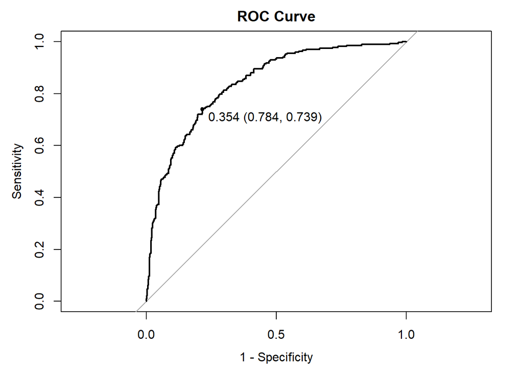

```r
plot(multi_roc , main = "ROC Curve", print.thres = TRUE, legacy.axes = TRUE)
```

```r
cat("The area under the curve is:", multi_roc$auc, "\n")
```

```
## The area under the curve is: 0.8394254
```

*Results: We Reject the Null Hypothesis*

## Logistic Regression

```r
# Converting the columns to categorical or factor
df_diab$Outcome <- as.factor(df_diab$Outcome)

# Splitting the dataset into training and testing sets (80:20 split)
# Setting seed
set.seed(123)
train_indices <- createDataPartition(df_diab$Outcome, p = 0.8, list = FALSE)
train_data <- df_diab[train_indices, ]
test_data <- df_diab[-train_indices, ]

# Fitting logistic regression model
log_reg <- glm(Outcome ~ ., data = train_data, family = "binomial")
log_reg
```

```
##
## Call:  glm(formula = Outcome ~ ., family = "binomial", data = train_data)
##
## Coefficients:
##              (Intercept)               Pregnancies                   Glucose
##               -7.8116450                 0.0998300                 0.0342306
##            BloodPressure             SkinThickness                   Insulin
##               -0.0148671                -0.0006103                -0.0007117
##                      BMI  DiabetesPedigreeFunction                       Age
##                0.0806695                 0.9355556                 0.0154356
##
## Degrees of Freedom: 614 Total (i.e. Null);  606 Residual
## Null Deviance:       796
## Residual Deviance: 598.4     AIC: 616.4
```

```r
# Making predictions on test data
predictions <- predict(log_reg, newdata = test_data, type = "response")

# Convert predicted probabilities to binary outcomes (0 or 1)
predicted_outcomes <- ifelse(predictions > 0.5, 1, 0)

# Setting levels of predicted outcomes to match levels of test data outcomes
predicted_outcomes <- factor(predicted_outcomes, levels = levels(test_data$Outcome))

# Calculating the confusion matrix
confusion <- confusionMatrix(predicted_outcomes, test_data$Outcome)

# Extracting the confusion matrix values
confusion$table
```

```
##           Reference
## Prediction  0  1
##          0 91 21
##          1  9 32
```

```r
# Extracting TP, FP, FN, TN from confusion matrix
tp <- confusion$table[2,2]
fp <- confusion$table[1,2]
fn <- confusion$table[2,1]
tn <- confusion$table[1,1]

# Calculating accuracy
accuracy <- (tp + tn) / sum(confusion$table)

# Calculating ROC (Receiver Operating Characteristic) curve
roc <- roc(test_data$Outcome, predictions)
# beta value for F-score
beta <- 1

# Calculate precision and recall
precision <- tp / (tp + fp)
recall <- tp / (tp + fn)

# Calculate F-score
f_score <- (1 + beta^2) * (precision * recall) / ((beta^2 * precision) + recall)


# Print results
cat("Confusion Matrix:\n", confusion$table, "\n")
```

```
## Confusion Matrix:
##  91 9 21 32
```

```r
cat("TP:", tp, "\n")
```

```
## TP: 32
```

```r
cat("FP:", fp, "\n")
```

```
## FP: 21
```

```r
cat("FN:", fn, "\n")
```

```
## FN: 9
```

```r
cat("TN:", tn, "\n")
```

```
## TN: 91
```

```r
cat("Accuracy:", accuracy, "\n")
```

```
## Accuracy: 0.8039216
```

```r
cat("AUC-ROC:", auc(roc), "\n")
```

```
## AUC-ROC: 0.8924528
```

```r
cat("F-score:", f_score, "\n")
```

```
## F-score: 0.6808511
```

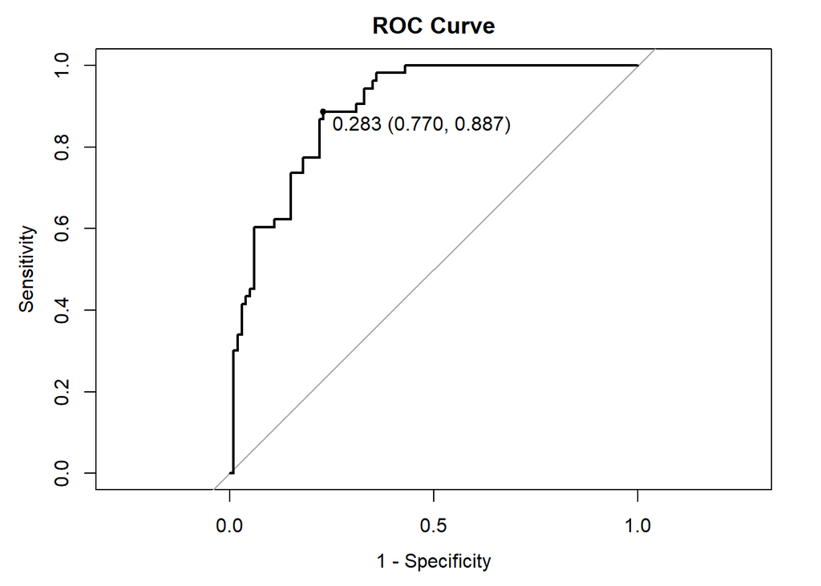

```r
plot(roc, main = "ROC Curve", print.thres = TRUE, legacy.axes = TRUE)
```

```r
summary(log_reg)
```

```
##
## Call:
## glm(formula = Outcome ~ ., family = "binomial", data = train_data)
##
## Deviance Residuals:
##     Min       1Q   Median       3Q      Max
## -2.4719  -0.7674  -0.4402   0.7776   2.9436
##
## Coefficients:
##                            Estimate Std. Error z value Pr(>|z|)
## (Intercept)              -7.8116450  0.7694301 -10.153  < 2e-16 ***
## Pregnancies               0.0998300  0.0358381   2.786  0.00534 **
## Glucose                   0.0342306  0.0040533   8.445  < 2e-16 ***
## BloodPressure            -0.0148671  0.0055567  -2.676  0.00746 **
## SkinThickness            -0.0006103  0.0076247  -0.080  0.93621
## Insulin                  -0.0007117  0.0009565  -0.744  0.45681
## BMI                       0.0806695  0.0165458   4.876 1.09e-06 ***
## DiabetesPedigreeFunction  0.9355556  0.3388561   2.761  0.00576 **
## Age                       0.0154356  0.0102718   1.503  0.13291
## ---
## Signif. codes:  0 '***' 0.001 '**' 0.01 '*' 0.05 '.' 0.1 ' ' 1
##
## (Dispersion parameter for binomial family taken to be 1)
##
##     Null deviance: 796.05  on 614  degrees of freedom
## Residual deviance: 598.41  on 606  degrees of freedom
## AIC: 616.41
##
## Number of Fisher Scoring iterations: 5
```

## Random Forest

```r
# Convert the Outcome column to factor
df_diab$Outcome <- as.factor(df_diab$Outcome)

# Split the dataset into training and testing sets (80:20 split)
# Set seed for reproducibility
set.seed(123)
train_indices <- createDataPartition(df_diab$Outcome, p = 0.8, list = FALSE)
train_data <- df_diab[train_indices, ]
test_data <- df_diab[-train_indices, ]

# Prepare predictor variables and target variable
predictors <- train_data[, -which(names(train_data) == "Outcome")]
target <- train_data$Outcome

# Train the random forest model
rf_model <- randomForest(x = predictors, y = target, ntree = 500, mtry = sqrt(ncol(predictors)))
rf_model
```

```
##
## Call:
##  randomForest(x = predictors, y = target, ntree = 500, mtry = sqrt(ncol(predictors)))
##                Type of random forest: classification
##                      Number of trees: 500
## No. of variables tried at each split: 3
##
##         OOB estimate of  error rate: 25.04%
## Confusion matrix:
##     0   1 class.error
## 0 344  56    0.140000
## 1  98 117    0.455814
```

```r
# Make predictions on the test data
test_predictors <- test_data[, -which(names(test_data) == "Outcome")]
test_predictions <- predict(rf_model, newdata = test_predictors)

# Convert predicted outcomes to factors
test_predictions <- as.factor(test_predictions)

# Calculate the confusion matrix
confusion <- confusionMatrix(test_predictions, test_data$Outcome)
confusion$table
```

```
##           Reference
## Prediction  0  1
##          0 90 18
##          1 10 35
```

```r
# Extract TP, FP, FN, TN from confusion matrix
tp <- confusion$table[2,2]
fp <- confusion$table[1,2]
fn <- confusion$table[2,1]
tn <- confusion$table[1,1]

# Calculate accuracy
accuracy <- (tp + tn) / sum(confusion$table)

# Calculate AUC-ROC
roc <- roc(test_data$Outcome, as.numeric(test_predictions))
auc_roc <- auc(roc)

# beta value for F-score
beta <- 1

# Calculate precision and recall
precision <- tp / (tp + fp)
recall <- tp / (tp + fn)

# Calculate F-score
f_score <- (1 + beta^2) * (precision * recall) / ((beta^2 * precision) + recall)

# Print results
cat("TP:", tp, "\n")
```

```
## TP: 35
```

```r
cat("FP:", fp, "\n")
```

```
## FP: 18
```

```r
cat("FN:", fn, "\n")
```

```
## FN: 10
```

```r
cat("TN:", tn, "\n")
```

```
## TN: 90
```

```r
cat("Accuracy:", accuracy, "\n")
```

```
## Accuracy: 0.8169935
```

```r
cat("AUC-ROC:", auc_roc, "\n")
```

```
## AUC-ROC: 0.7801887
```

```r
cat("F-score:", f_score, "\n")
```

```
## F-score: 0.7142857
```

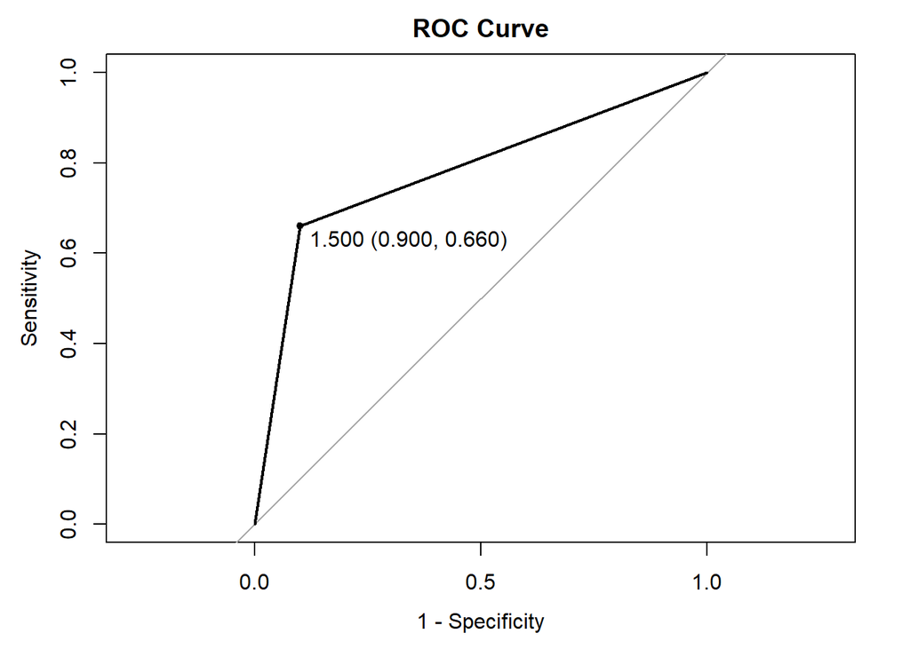

```r
plot(roc, main = "ROC Curve", print.thres = TRUE, legacy.axes = TRUE)
```

## Conclusion

**1. We have developed a models that uses Logistic Regression and Random Forest.**  
**2. The best model has an accuracy of 0.81699, or 81.6%, in predicting gestational diabetes in pregnant women.**  
**3. We also used a one-way ANOVA model for the diabetes pedigree function, which determines whether the disease is inherited or not, and assessed it using the chance that an individual has inherited diabetes.**  
**4. We also performed a multivariate logistic regression, which clarifies whether a trait is important in predicting diabetes or not.**